# Spaces

Analytics Guild

01/01/2022

## Setup

Loading libraries and data.

## Visualize New Members

Data: analytics/s3_data_activity/discord/raw_data

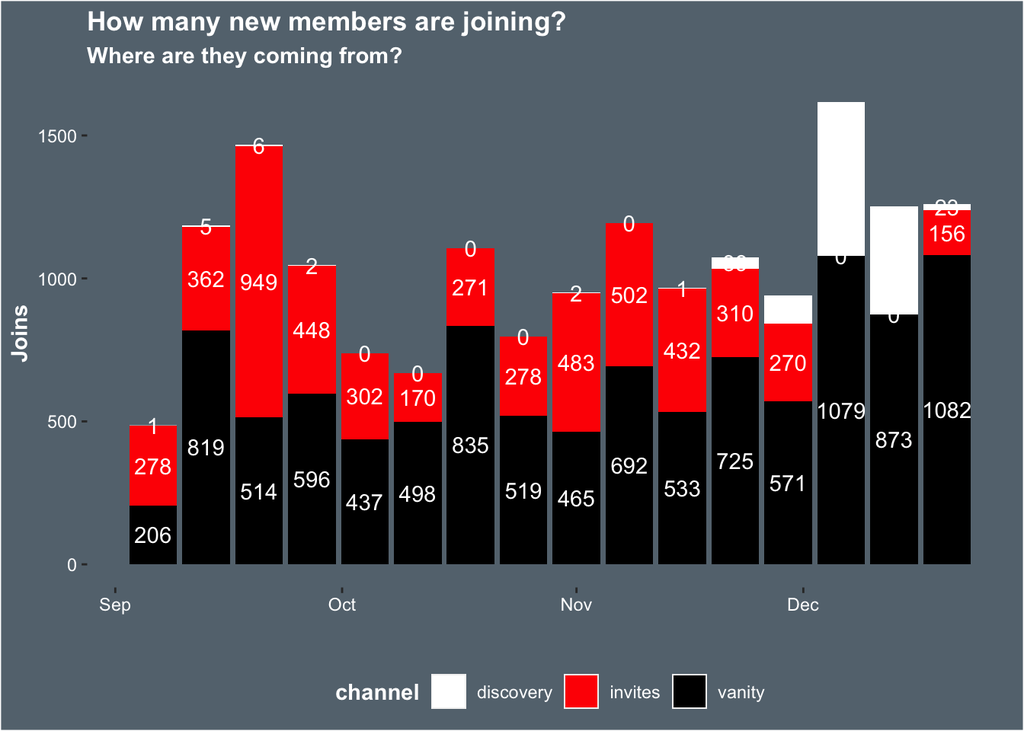

## Visualize Total Member

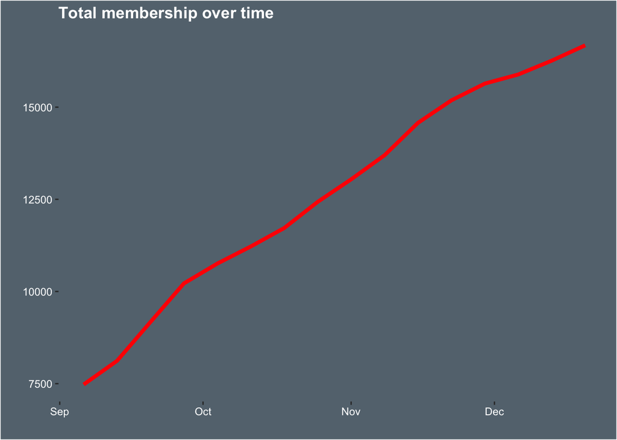

## Visualize First Day Activation

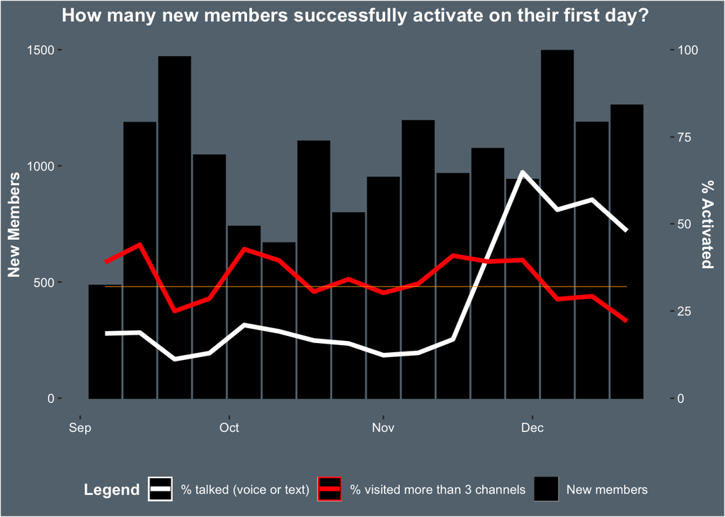

## Visualize Next Week Retention

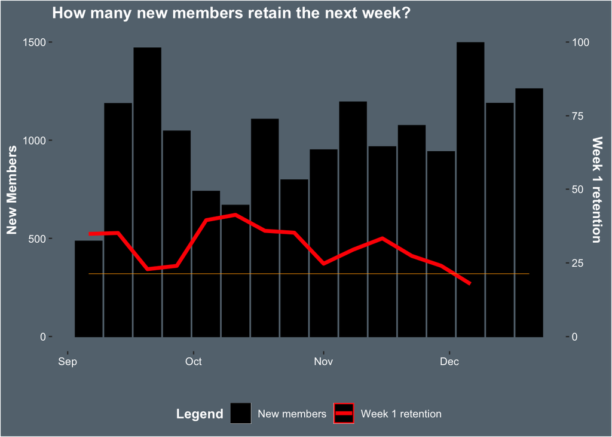

## Visualize Visitors & Communicators

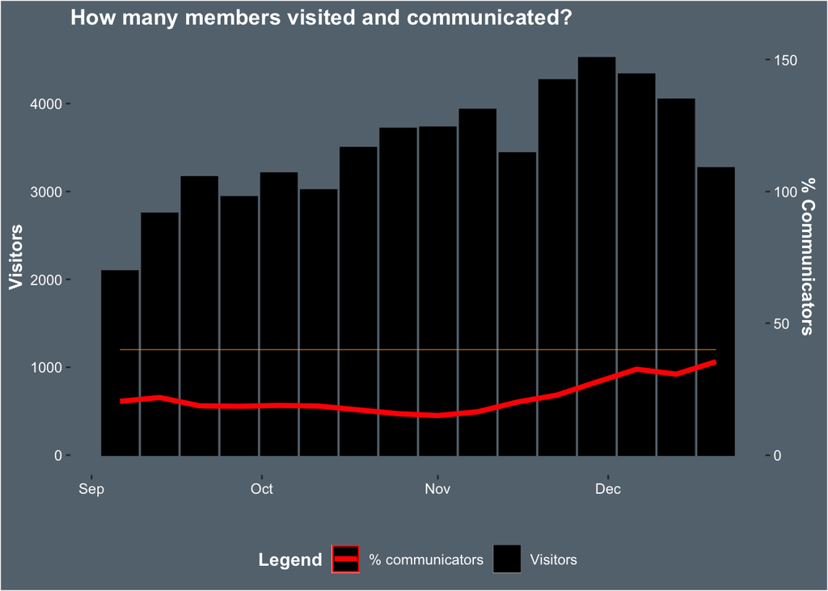

## Visualize Message - Avg Messages

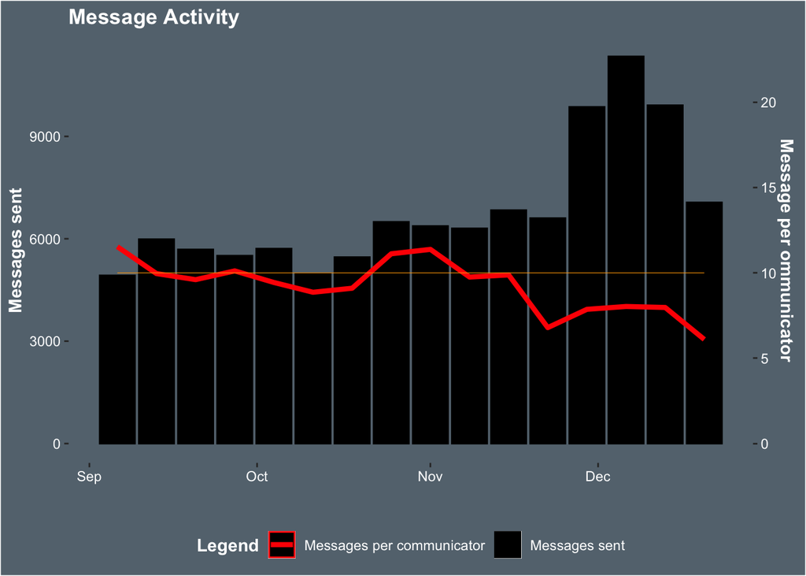

## Visualize Voice Activity

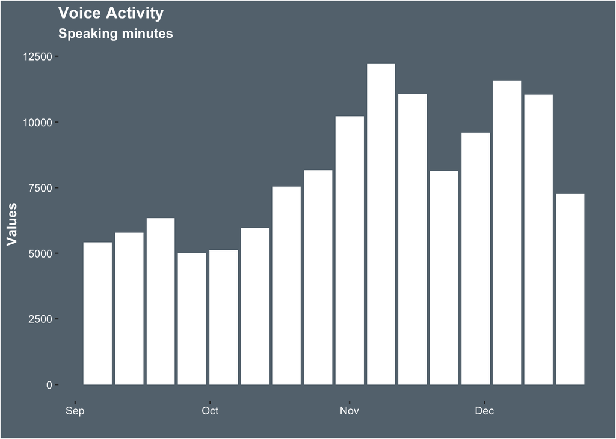

## Visualize Snapshot Votes

Data: analytics/s3_data_activity/snapshot/raw_data

```
## # A tibble: 8 x 3
## # Groups:   proposal_id [8]
##   proposal_id                               title                              n
##   <chr>                                     <chr>                          <int>
## 1 0xabccf8394b35e92043a4055f8430f1babd44fd… Execute swap with Tokemak for…  1515
## 2 QmYmHuawgkCZxVMo6EHq5s2WxQrSwTYZeBGRfFkc… Bankless DAO Treasury Multi-s…   535
## 3 QmWwN1CeDPLcvCVkDuBiYmaaNcRhfrUzFYhBixF2… Bankless DAO Season 2 Grants …   523
## 4 QmeUcnL5FTpF2ah2CCph6DZGqJzG19coT9b3ECLA… Season 2 Project and Guild Fu…   480
## 5 QmVm6jzr7yDRiBmmkvCQ1MFw4jTaiJcME6ZNBp4Q… Retro Rectification Donations    464
## 6 QmWjyeUFLmvVLg3fYeNWLjPscy6u4JU2tv8A1E1q… Olympus Pro BANK liquidity bo…   435
## 7 QmcL7qZ4nA3NoTukMVXXZeramGA8QiqQSpdBFAuR… S1 & S2 Grants Committee Comp…   395
## 8 QmZhncmagTnWXjvX17Kmm1f25D33CPAw6f1UQBo7… Balancer Liquidity Mining Pro…   341
```

## Grants Committee Fund Distribution: Stacked Bar Chart

Note: For comparison between S1 and S2 where available.

SQL Query: See DaoDash `Fund_Flow_GC_2`. Note dates between S1 and S2. Same query used for Sankey.

**NOTE**: May need to add Treasury Guild as another potential source of funds (confirm Treasury address).

```r
# --Season 1 (116 rows): timestamp_display < '2021-10-08'::DATE AND timestamp_display > '2021-06-14'::DATE  -- TOTAL: 11,288,361.28706
# --Season 2 (426 rows): timestamp_display > '2021-10-07'::DATE AND timestamp_display < '2022-01-08'::DATE  -- TOTAL: 10,780,178.00001

#WITH fund_flow AS (
#select
#  'Out' as Direction,
#   ssb.from_address,
#   w.human_readable,
#   w.entity_type,
#   ssb.amount_display,
#   ssb.timestamp_display,
#   ssb.to_address
#from stg_subgraph_bank_1 ssb
#join public.bankless_wallet_entity_2 w on lower(ssb.from_address) = lower(w.wallet_address)
#-- note 'Out' is from_address

#union all

#select
#  'In' as Direction,
#  ssb.from_address,
#  w.human_readable,
#  w.entity_type,
#  ssb.amount_display,
#  ssb.timestamp_display,
#  ssb.to_address
#from stg_subgraph_bank_1 ssb
#join public.bankless_wallet_entity_2 w on lower(ssb.to_address) = lower(w.wallet_address)
#-- note 'In' is to_address
#),

#gcs1 AS (
#SELECT
#  direction,
#  from_address,
#  human_readable AS readable,
#  entity_type,
#  amount_display,
#  timestamp_display,
#  to_address
#FROM fund_flow
#WHERE entity_type = 'Grants Committee'
#AND timestamp_display > '2021-10-07'::DATE
#AND timestamp_display < '2022-01-08'::DATE
#AND direction = 'Out'
#--where timestamp_display > '2021-10-01T09:26:59'::TIMESTAMP
#ORDER BY timestamp_display DESC
#)

#SELECT
#  g.direction,
#  g.from_address,
#  g.readable,
#  g.entity_type,
#  g.amount_display,
#  g.timestamp_display,
#  g.to_address,
#  b.human_readable
#FROM gcs1 g
#LEFT JOIN bankless_wallet_entity_2 b ON lower(g.to_address) = lower(b.wallet_address)
```

Visualization

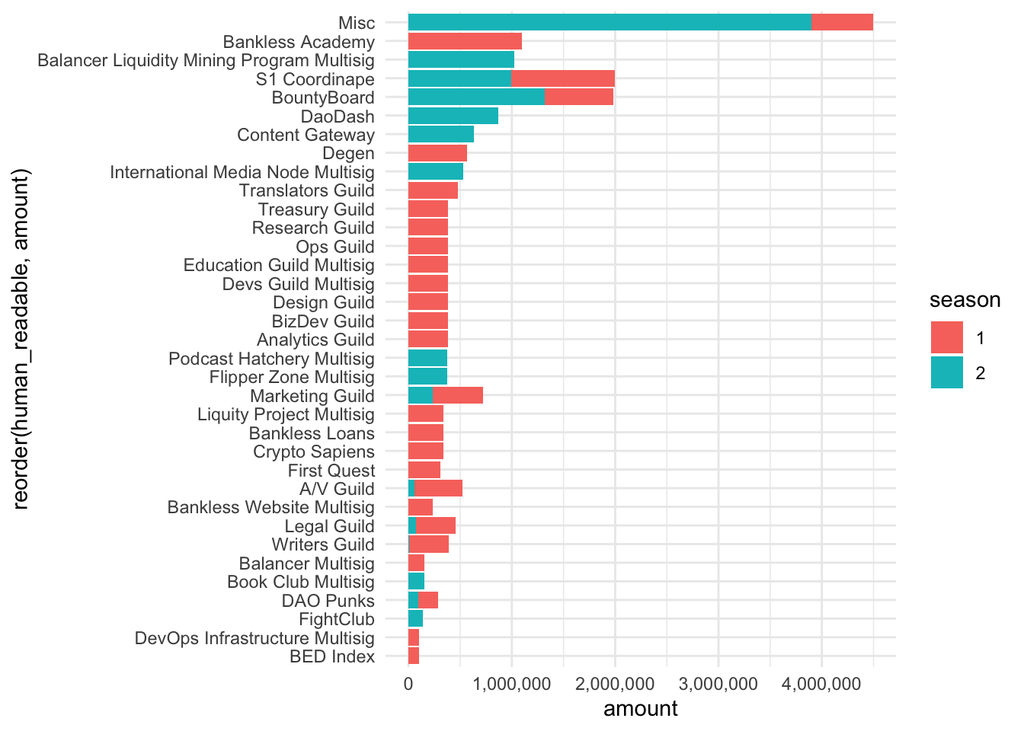

## Bankless Vault Fund Distribution

**Note**: In Season 1, Analytics Guild received funds from the Grants Committee address, in Season 2, the Analytics Guild received funds from the Bankless Vault address.

See DaoDash: `Fund_Flow_Bankless_Vault` (nearly identical to `Fund_Flow_GC_2`, except direction is ‘In’).

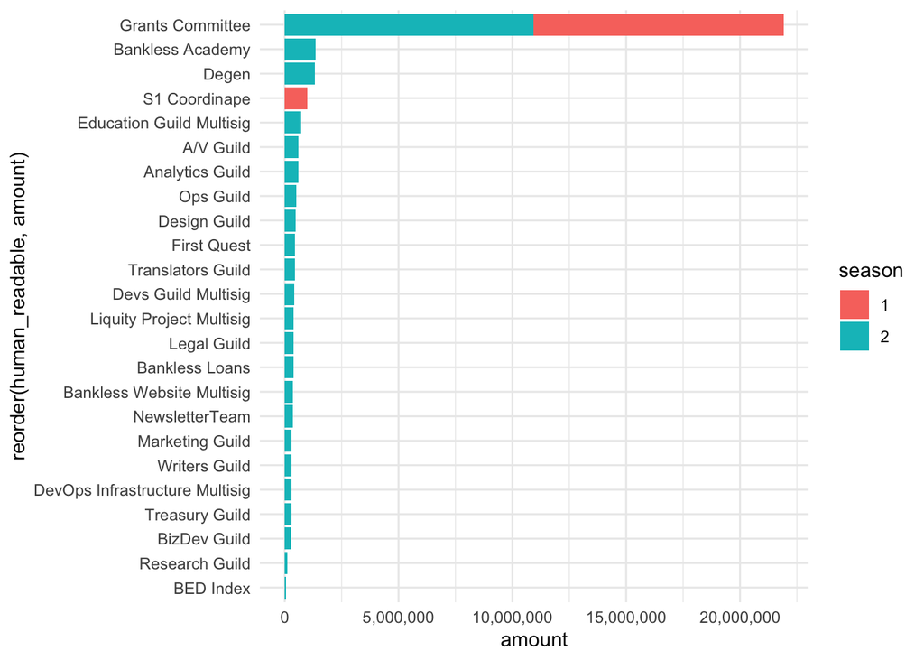

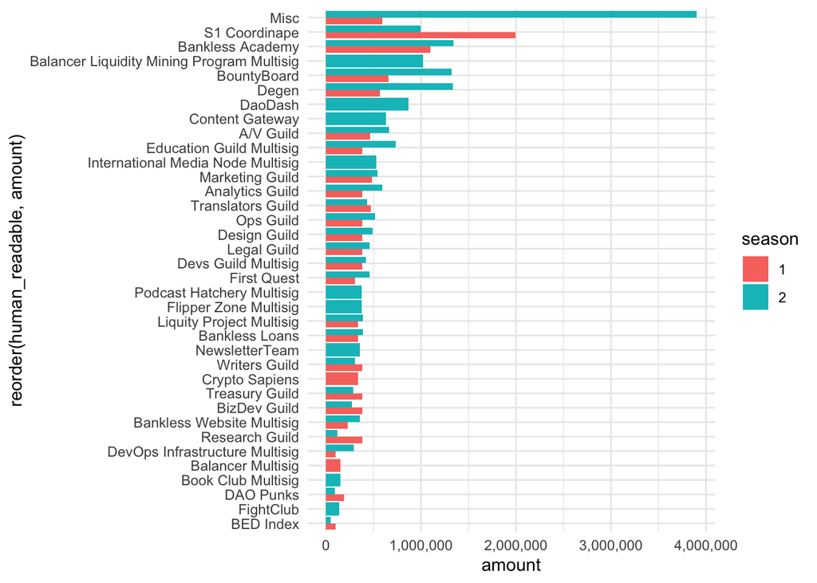

## Example Sankey

[interactive chart not shown]

## Grants Committee Season 1 Sankey

Workflow

Step 1: Replace `NA` values. Note: `NA` values step from having new projects, guilds pop up after the creation of `bankless_wallet_entity` table in DaoDash, so be sure to update that table before proceeding.

Step 2: =create a `my_links` table, Step 2a: a `my_nodes` table, Step 2b: create IDSource, IDTarget columns Step 2c: create `my_color` object.

Step 3: Create sankey w/ SankeyNetwork() function and library.

**NOTE** For comparison between Grants Comm distribution S1 vs S2, use side-by-side bar chart.

```
## Links is a tbl_df. Converting to a plain data frame.
```

[interactive chart not shown]

## Grants Committee Season 2 Sankey

NOTE: Need to consult this [sheet](https://docs.google.com/spreadsheets/d/1a6ZMclYkESWNwV7xNhT-LELwHtK28wo9f4xx-JGab5k/edit#gid=0) to add additional project, guild multisig & address to `bankless_wallet_entity` table in DAODash.

```
## Links is a tbl_df. Converting to a plain data frame.
```

```
## Nodes is a tbl_df. Converting to a plain data frame.
```

[interactive chart not shown]

## REVISED Sankey: Grants Committee Vault, Season 1

NOTE: full_grants <- rbind(gcs1a, gcs2a, bv_s1a, bv_s2a)

- full_grants combines grants committee + bankless_vault, across s1 and s2
- start with full_grants

```
## # A tibble: 27 x 1
##    name
##    <chr>
##  1 BountyBoard
##  2 A/V Guild
##  3 Bankless Academy
##  4 Analytics Guild
##  5 Degen
##  6 Bankless Loans
##  7 Writers Guild
##  8 Devs Guild Multisig
##  9 Translators Guild
## 10 Treasury Guild
## 11 Ops Guild
## 12 Design Guild
## 13 Research Guild
## 14 Marketing Guild
## 15 First Quest
## 16 Bankless Website Multisig
## 17 Liquity Project Multisig
## 18 S1 Coordinape
## 19 BED Index
## 20 BizDev Guild
## 21 DAO Punks
## 22 Crypto Sapiens
## 23 Legal Guild
## 24 Education Guild Multisig
## 25 DevOps Infrastructure Multisig
## 26 Balancer Multisig
## 27 Misc
```

```
## Links is a tbl_df. Converting to a plain data frame.
```

[interactive chart not shown]

## REVISED Sankey: Grants Committee Vault, Season 2

```
## # A tibble: 34 x 1
##    name
##    <chr>
##  1 BountyBoard
##  2 A/V Guild
##  3 DaoDash
##  4 FightClub
##  5 Content Gateway
##  6 Writers Guild
##  7 Marketing Guild
##  8 S1 Coordinape
##  9 DAO Punks
## 10 Legal Guild
## 11 Balancer Liquidity Mining Program Multisig
## 12 International Media Node Multisig
```

[output cut: 22 more lines]

```
## Links is a tbl_df. Converting to a plain data frame.
```

[interactive chart not shown]

## Number of Bank Holders (Membership Categories); S1 vs S2

**Task**: Compare S1 vs S2 on all membership categories.

**Challenge**: Inconsistent results using very similar queries across DaoDash, Dune Analytics and Google BigQuery. Use Dune Analytics for now, reconcile sources in S3.

**NOTE**: Cummulative

See `mem_1_10K_bank_holdings_time_range` and other segments downloaded in raw csv. Data gathered from DAODash table:

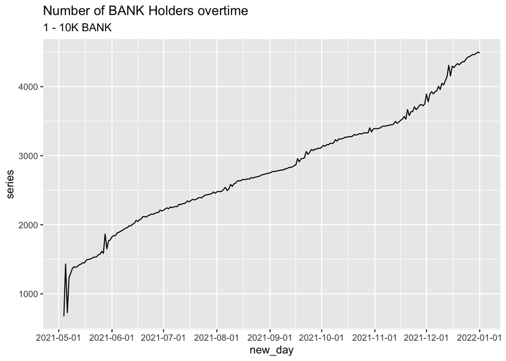

## BANK Holders 10 - 35K

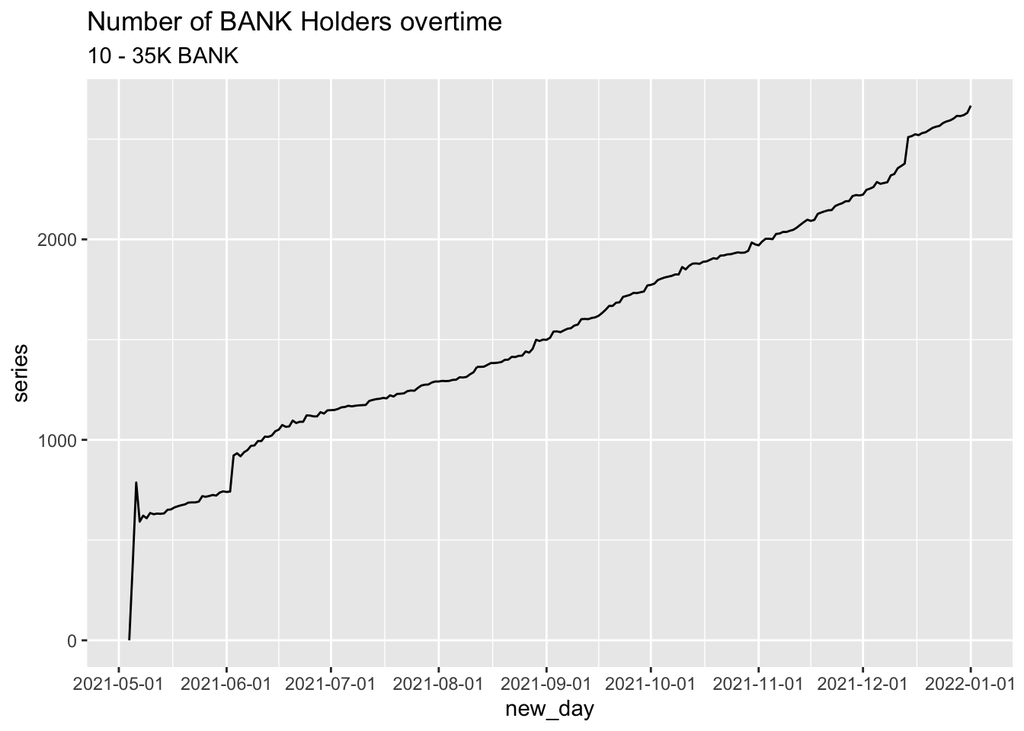

## BANK Holders 35 - 150K

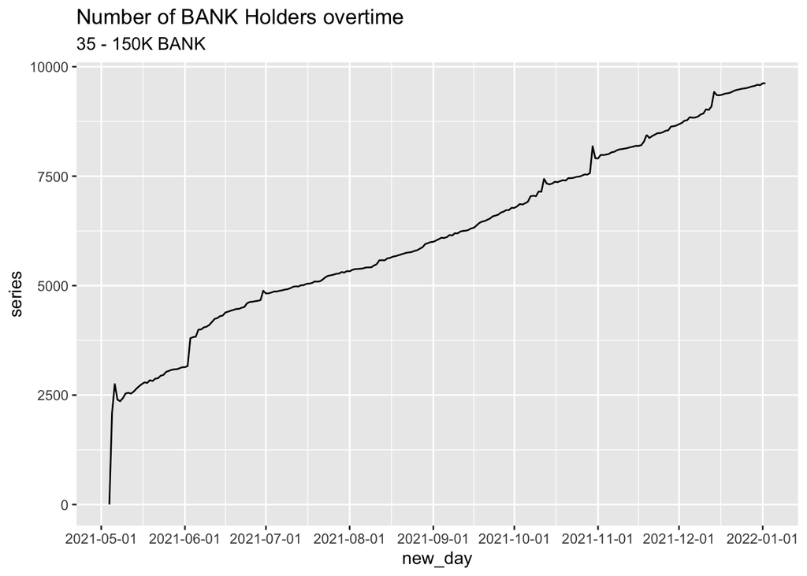

## BANK Holders 150K - 1.5M

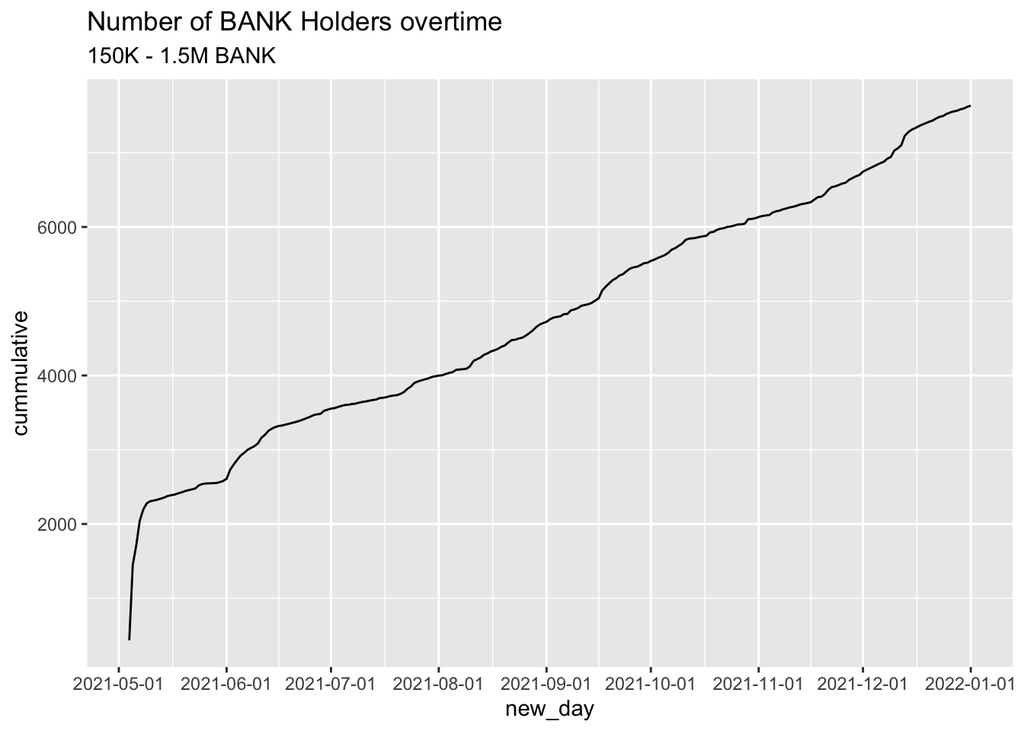

## Coordinape Distribution

**Task**: Query comparison of tokens/bank distributed via Coordinape in S1 vs S2.

**Challenge**: See DaoDash query, `Seasonal Coordinape Distribution`

**Request**: Reach out to Saul for coordinape network visual growth s1 to s2.

Create dataframe / tibble.

```
## # A tibble: 1 x 1
##   sum_tokens
##        <dbl>
## 1     192076
```

```
## # A tibble: 1 x 1
##   sum_tokens
##        <dbl>
## 1     425561
```

```
## # A tibble: 302 x 2
##    sender_id     n
##        <dbl> <int>
##  1      2225   286
##  2      2202   278
##  3      2075   274
##  4      2178   271
##  5      2167   211
##  6      2240   128
##  7      2268   120
##  8      2056   112
##  9      2173   102
## 10      2267   100
## # … with 292 more rows
```

```
## # A tibble: 1 x 1
##       n
##   <int>
## 1   302
```

```
## # A tibble: 1 x 1
##       n
##   <int>
## 1   458
```

```
## # A tibble: 1 x 1
##       n
##   <int>
## 1   416
```

```
## # A tibble: 1 x 1
##       n
##   <int>
## 1   481
```

## POAP Distribution

**Task**: Find number of POAPs claimed for Community Calls S1 vs S2

**Progress**: Query Content Gateway API endpoint:

https://prod-content-gateway-api.herokuapp.com/api/v1/graphql

Query historical -> PoapV1 -> PoapTokenV1s

Can query all events containing “Bankless DAO Community” (for community call poaps), but still need to find *number of poaps* claimed at each event.

Query: Combine GC API and programmatically get tokens distributed for each event.

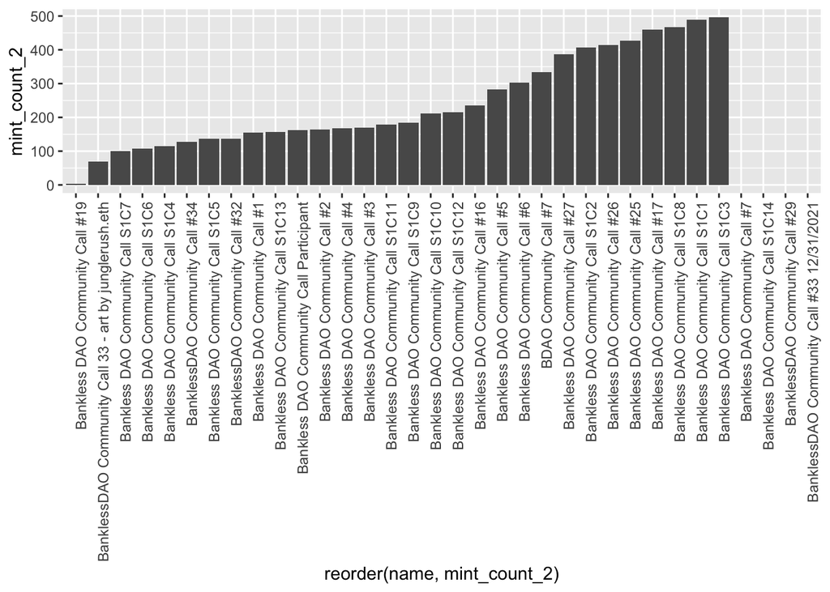

Query from Content Gateway API Endpoint. https://prod-content-gateway-api.herokuapp.com/api/v1/graphql

NOTE: Used POAP.xyz subgraph API

## Bounty Board

**Task**: Query total number of bounties and total value committed to bounties between S1 v S2.

**Challenge**: query from database in prod. WIP.

Number of bounties: S1: 40, S2: 66+

Value committed to bounties: S1: 68K, S2: 209K

Update: 15/01/22 for numbers

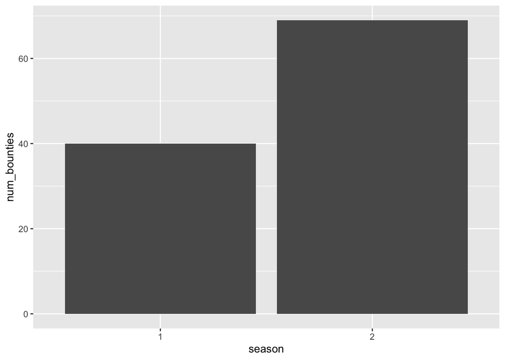

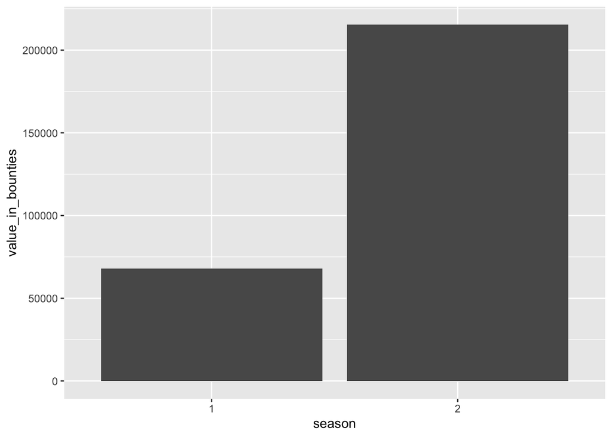

## Discourse

Task: Connect to API to query forum posts with polls and number of people voting.

Challenge: API documentation does not mention Polls or Votes. See [documentation](https://docs.discourse.org/) here.

Progress: Established API connection with the `pydiscourse` https://github.com/BanklessDAO/analytics/blob/main/discourse_forum/api_connection.py

Ended up downloading CSV manually of all users, instead of votes, will track other engagement metrics like: - topics_entered - posts_read_count - time_read - topic_count

*note*: remove email column, then save raw data to github

## First Quest

Task: Query number of new members going through First Quest

**Challenge**: Data inserted at 2021-11-18, might have insufficient data to make S1 vs S2 comparison.

Just show S2 First Quest data standalone (compare Funnel shape from two time periods).

## Tips Given & Received

**Task**: Get comparison between S1 and S2, create tibble/dataframe to display data.

**Data**: See DaoDash query: `Seasonal Tip Distribution`

Season 1 Tip Distribution (2873 rows, 983,019 tips given), WHERE timestamp < ‘2021-10-08’::DATE AND timestamp > ‘2021-06-14’::DATE

Season 2 Tip Distribution (1336 rows, 337,173 tips given), WHERE timestamp > ‘2021-10-07’::DATE AND timestamp < ‘2022-01-08’::DATE

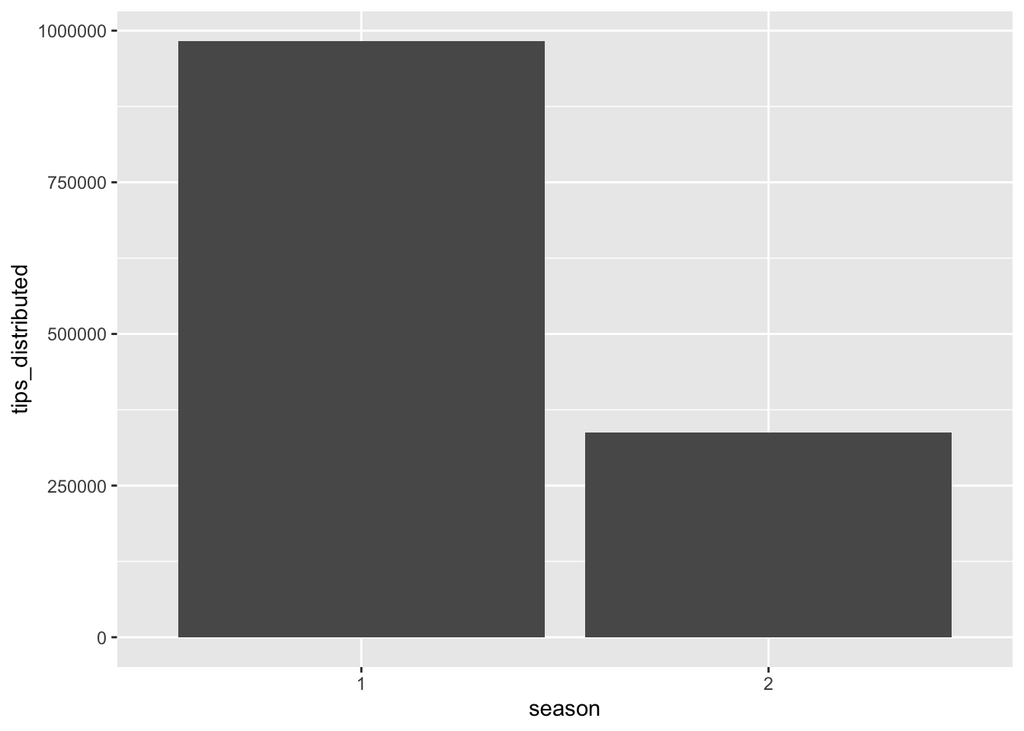